# メッシュデータによる商業統計の可視化

# メッシュデータ

**境界データのダウンロード**

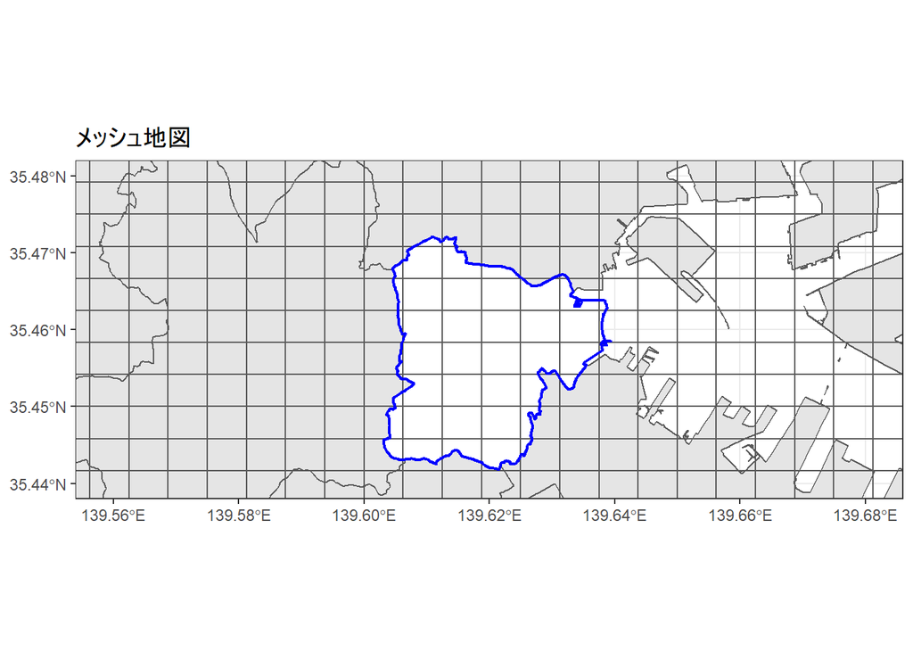

```r
mesh_1<-
  read_sf("500MESH/HDDSWH5339/MESH05339.shp")

#メッシュ地図を重ねる．
ggplot()+
  geom_sf(data=Yokohama_shi_map)+
  geom_sf(data=Nishi_ku_map, fill="white")+
  geom_sf(data=mesh_1, fill="NA")+
  geom_sf(data=Nishi_ku_map, fill="NA",
          size=0.8, color="blue")+
  coord_sf(xlim =  c(139.56, 139.68), ylim = c(35.44, 35.48))+
  ggtitle("メッシュ地図")+
  theme_bw()
```

```r
commercial<-read.csv("03_500m_c/H26_03_500m市区町村.csv",
                  header=FALSE, sep=",")
```

```r
commercial %>%
  mutate(KEY_CODE=V5*100000+V6*1000+V7*100+V8) ->
  commercial

commercial %>%
  mutate(KEY_CODE=as.character(KEY_CODE)) ->
  commercial
```

```r
meshcommercial_1<-
  left_join(mesh_1, commercial) %>%
  distinct(KEY_CODE, .keep_all = TRUE)
proj<-
  "+proj=longlat +datum=WGS84 +ellps=WGS84 +towgs84=0,0,0"

meshcom_1_proj<-
  meshcommercial_1 %>%
  st_transform(proj)

Nishi_ku_proj<-
  Nishi_ku_map %>%
  st_transform(proj)
```

```r
st_agr(meshcom_1_proj)="constant"
st_agr(Nishi_ku_proj)="constant"

#神奈川区のメッシュデータの完成
mesh_intersection_1<-
  st_intersection(x=meshcom_1_proj, y=Nishi_ku_proj)
```

```r
#欠損値NAを０にするように指示
mesh_intersection_1[is.na(mesh_intersection_1$V22),]$V22<-0
```

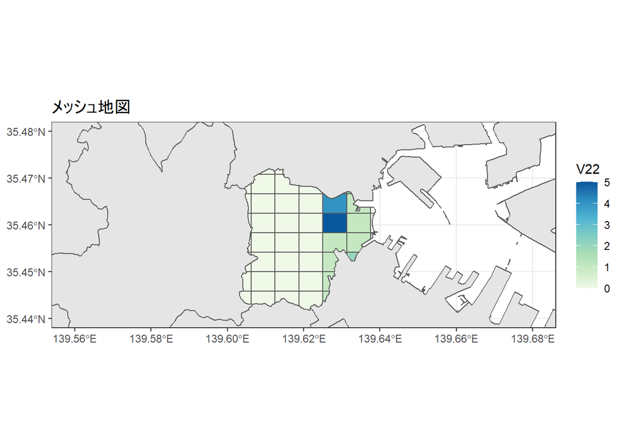

```r
#可視化
ggplot()+
  geom_sf(data=Yokohama_shi_map)+
  geom_sf(data=mesh_intersection_1, aes(fill=V22))+
  scale_fill_distiller(palette="GnBu", direction=1)+
  coord_sf(xlim =  c(139.56, 139.68), ylim = c(35.44, 35.48))+
  ggtitle("メッシュ地図")+
  theme_bw()
```

# 商業統計データ

**Rによる地理空間データの可視化**

- チュートリアル[ホーム](https://shinichiro-iwata.github.io/geospatial-data-visualization/)